# The inla.posterior.sample.eval-function

Haavard Rue

KAUST, Aug 2022

## Introduction

This short note add some more explanation to the `inla.posterior.sample.eval()`-function, as its a constant source of confusing (which is understandable). The purpose of this function is to ease function-evaluations of samples from the fitted model.

## Simple example

As often, its easier to work with an example.

```r
n <- 100
x <- rnorm(n)
eta <- 1 + x
y <- rnorm(n, mean = eta, sd = 0.1)
r <- inla(y ~ 1 + x,
    data = data.frame(y,x),
    control.compute = list(config=TRUE))
```

where the *config* argument is required. We can now generate samples from the fitted model

```r
samples <- inla.posterior.sample(10000, r)
```

Here, *samples* contains the samples, but in long vectors with additional information about where to find what which makes it complicated.

The information available is what is in the output

```r
summary(r)
```

```
Time used:
    Pre = 0.356, Running = 0.415, Post = 0.0471, Total = 0.818
Fixed effects:
             mean    sd 0.025quant 0.5quant 0.975quant  mode kld
(Intercept) 0.990 0.010      0.971    0.990      1.009 0.990   0
x           0.995 0.011      0.974    0.995      1.016 0.995   0

Model hyperparameters:
                                          mean    sd 0.025quant 0.5quant
Precision for the Gaussian observations 108.27 15.31      80.39   107.55
                                        0.975quant   mode
Precision for the Gaussian observations     140.30 106.11

Marginal log-Likelihood:  74.36
 is computed
Posterior summaries for the linear predictor and the fitted values are computed
(Posterior marginals needs also 'control.compute=list(return.marginals.predictor=TRUE)')
```

so its **x**, **(Intercept)** and the **Precision for the Gaussian observations**, plus the linear predictor(s).

The `...eval()` function simplifies the evaluation of a function over (joint) samples, by assigning sample-values to each variable. To extract samples of **x**, which is here the regression coefficient for the covariates $x$ (this is confusing, I know), then we can do

```r
fun1 <- function() return (x)
```

We can now evaluate `fun1` for each sample, using the `...eval()`-function, like

```r
eval.fun1 <- inla.posterior.sample.eval(fun1, samples)
str(eval.fun1)
```

```
 num [1, 1:10000] 0.996 0.974 1.033 0.973 0.993 ...
 - attr(*, "dimnames")=List of 2
  ..$ : chr "fun[1]"
  ..$ : chr [1:10000] "sample:1" "sample:2" "sample:3" "sample:4" ...
```

since **x** is automatically assigned the sample value before `fun1` is called. This happens for each sample.

We can compare with the the INLA-output

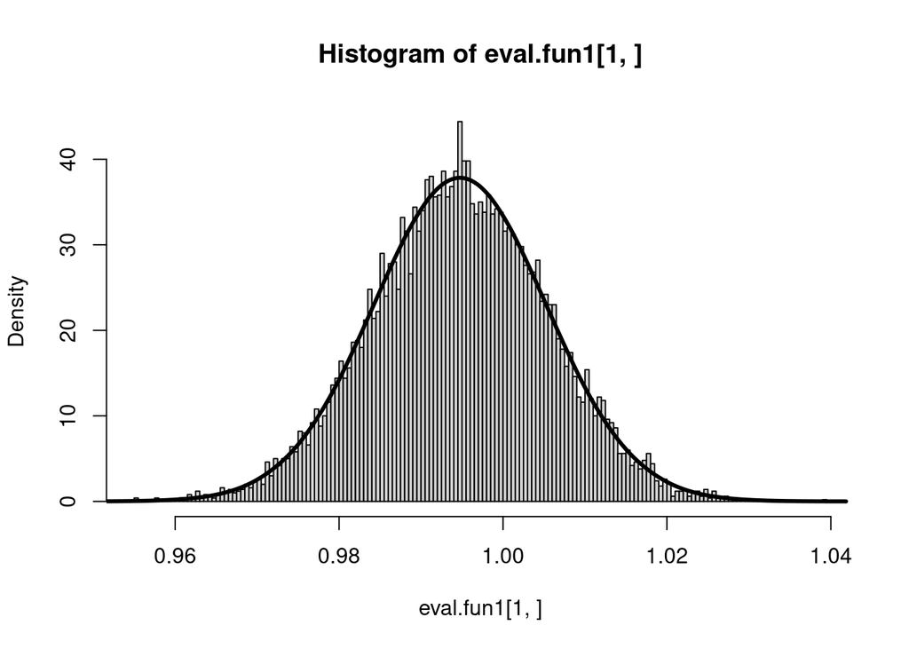

```r
hist(eval.fun1[1,], prob=TRUE, n=300)
lines(inla.smarginal(r$marginals.fixed$x), lwd=3)
```

and the results seems to agree.

Also the variable **(Intercept)** is automatically created, but since this form is awkward to use in **R**, it is equivalent to **Intercept**. We can for example sample the linear predictor with

```r
fun2 <- function(x.cov) return (Intercept + x * x.cov)
```

Here, we need to pass the covariates $x$ (which is *not* the same as **x**) separately as a named argument,

```r
eval.fun2 <- inla.posterior.sample.eval(fun2, samples, x.cov = x)
```

and we plot the regression-line

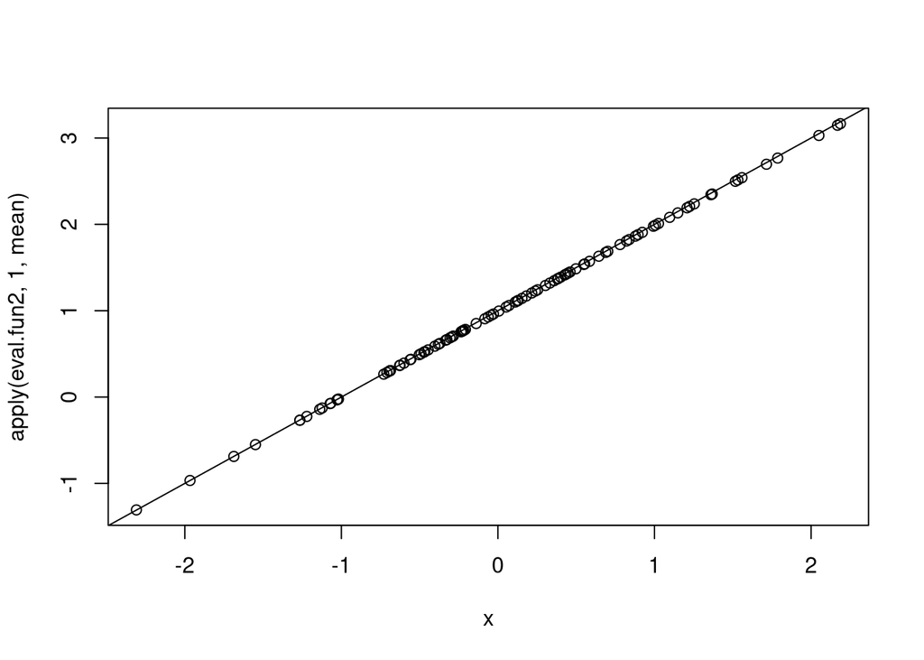

```r
plot(x, apply(eval.fun2, 1, mean))
abline(a=1, b=1) # this is the true curve
```

The predictor is also available automatically as **Predictor**, so

```r
fun3 <- function(x.cov) return (Predictor - (Intercept + x * x.cov))
eval.fun3 <- inla.posterior.sample.eval(fun3, samples, x.cov = x)
summary(eval.fun3[1,])
```

```
      Min.    1st Qu.     Median       Mean    3rd Qu.       Max.
-5.551e-17  0.000e+00  0.000e+00 -4.330e-19  0.000e+00  5.551e-17
```

as it should.

## Samples of hyper-parameters

It gets a little more involved with the hyper-parameters. In the example above, there is only one, the precision for the observational noise. We can use this to sample new data from the fitted model. Hyper-parameters are automatically assigned values in the vector **theta**.

```r
fun4 <- function() return (theta)
eval.fun4 <- inla.posterior.sample.eval(fun4, samples)
table(eval.fun4[1, ])
```

```
61.6805110845198 72.4385684238382 81.7214907590682  92.194009312955
              11               93              541             1452
99.9110790781138 108.274103674873 116.734301678518 125.855552951889
            1969             1915             2031             1435
140.890989984769 157.722647855486
             505               48
```

A feature here, is that only the integration points for **theta** are used, hence samples of **theta** are discrete with finite number of values. (To only sample the hyper-parameters, please use function `inla.hyperpar.sample()`.) Note that **theta**, by default, is the hyper-parameters in the user-scale (like precision, correlation, etc). If argument `intern=TRUE` is used in the `inla.posterior.sample()`-function, then they will appear in the internal-scale (like `log(precision)`, etc).

We can generate a new dataset from the fitted model, with

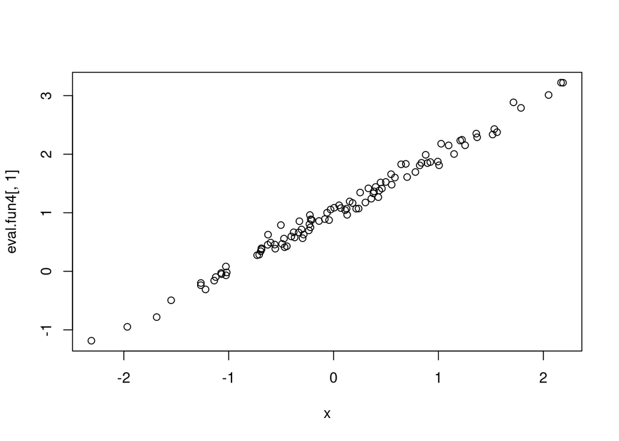

```r
samples <- inla.posterior.sample(1, r)
fun4 <- function() {
    n <- length(Predictor)
    return (Predictor + rnorm(n, sd = sqrt(1/theta)))
}
eval.fun4 <- inla.posterior.sample.eval(fun4, samples)
plot(x, eval.fun4[,1])
```

With more than one hyper-parameter, then `theta` is vector, and the order of hyper-parameters is the same as is stored in the result-object. The user has to organise this manually. With

```r
r <- inla(y ~ 1 + x,
    family = "sn",
    data = data.frame(y,x),
    control.compute = list(config=TRUE))
```

then

```r
rownames(r$summary.hyperpar)
```

```
[1] "precision for skew-normal observations"
[2] "Skewness for skew-normal observations"
```

so that `theta[1]` is the precision while `theta[2]` is the skewness.

## Example: Predictor with and without random effects

Here is an example that pops up from time to time, using the tools above. We are interested in comparing the linear predictor with and without some random effects. The below example is artificial but shows how this works.

First we simulate some data

```r
m <- 100
n <- m^2
## fixed effects
x <- rnorm(n)
xx <- rnorm(n)
## random effects
v <- rnorm(m, sd=0.2)
v.idx <- rep(1:m, each = m)
eta <- 1 + 0.2 * (x + xx) + v
y <- rpois(n, exp(eta))
```

and then fit the model

```r
r <- inla(y ~ 1 + x + xx + f(v.idx, model = "iid"),
          data = data.frame(y, x, xx, v.idx),
          family = "poisson",
          control.compute = list(config = TRUE))
samples <- inla.posterior.sample(10000, r)
```

Now we want to compare the linear predictor with and without the `f(v.idx, model = "iid")` term. The easy way out, is to use the predictor and then subtract the iid-term, instead of building it up manually.

```r
fun5 <- function(v.index) {
    return (c(Predictor, Predictor - v.idx[v.index]))
}
eval.fun5 <- inla.posterior.sample.eval(fun5, samples, v.index=v.idx)
```

And we can compare with and without for some components

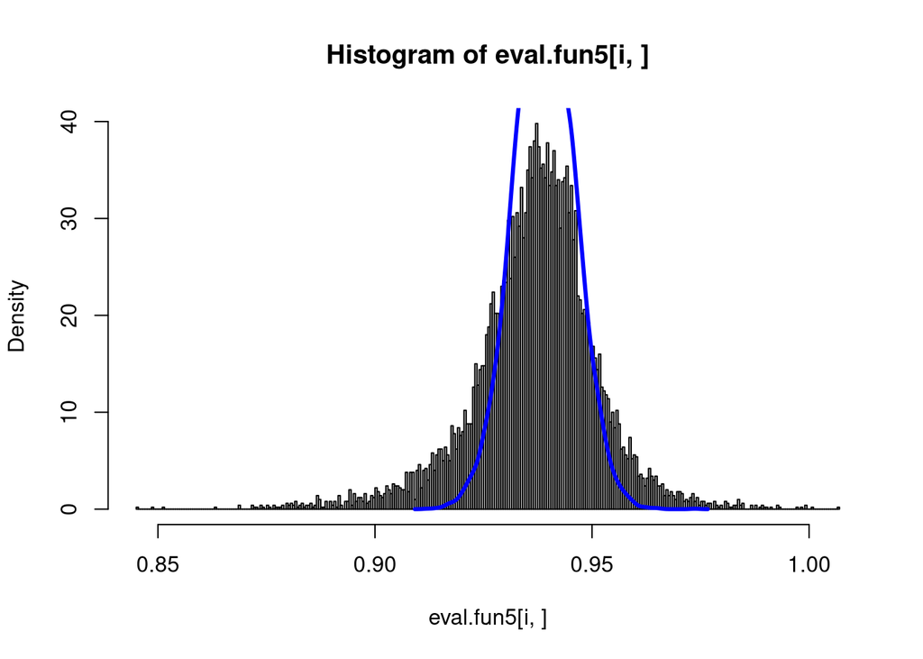

```r
i <- 2
hist(eval.fun5[i,], prob=TRUE, n=300)
lines(density(eval.fun5[n + i,]), col="blue", lwd=3)
```

## Predictor $A$-matrix (experimental-mode only)

For some models, especially models using the SPDE, then a projector matrix is used, so we need the A-matrix for the predictor. Often this looks like

```r
r <- inla(...., control.predictor = list(A=inla.stack.A(...)))
```

For these models, then the observations depend on $\eta^*$, where $\eta^* = A \eta$, and $\eta$ is defined with the formula. In these cases, then `Predictor` is $\eta$ and `APredictor` is $\eta^*$. Moreover, the $A$ matrix is available as `pA` in the `...eval()`-function.

Here is the same example above, with a random $A$-matrix showing how to use this.

```r
n <- 100
m <- 25
## fixed effects
x <- rnorm(n)
xx <- rnorm(n)
## random effects
v <- rnorm(m, sd=0.2)
v.idx <- rep(1:m, each = n %/% m)
eta <- 1 + 0.2 * (x + xx) + v
A <- matrix(rnorm(n^2, sd=sqrt(1/n)), n, n)
eta.star <- A %*% eta
y <- rpois(n, exp(eta.star))

r <- inla(y ~ 1 + x + xx + f(v.idx, model = "iid"),
          data = data.frame(y, x, xx, v.idx),
          family = "poisson",
          inla.mode = "experimental",
          control.predictor = list(A=A),
          control.compute = list(config = TRUE))
samples <- inla.posterior.sample(10000, r)
```

We will compare the same change, with and without the iid-term.

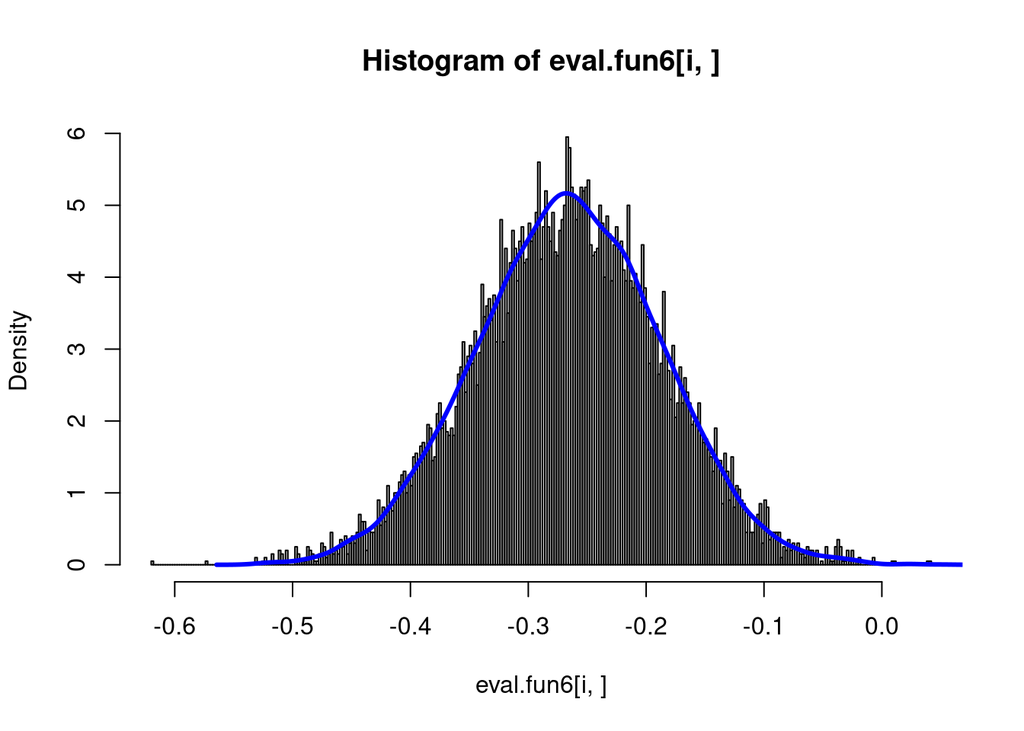

```r
fun6 <- function(v.index) {
    return (c(APredictor, as.numeric(pA %*% (Predictor - v.idx[v.index]))))
}
eval.fun6 <- inla.posterior.sample.eval(fun6, samples, v.index=v.idx)
i <- 2
hist(eval.fun6[i,], prob=TRUE, n=300)
lines(density(eval.fun6[n + i,]), col="blue", lwd=3)
```